# Aracılık Etkisi

2024-09-03

Bu oturumda kullanılan paketler…

```r
library(GGally)       ## değişkenler arasındaki ilişkiyi inceleme
library(lavaan)       ## Yem analizleri
library(broom)        ## sonuçların düzgün elde edilmesi
library(DT)           ## interaktif tablolar
library(dplyr)        ## veri düzenleme
library(knitr)        ## rapor ve tablo oluşturma
library(semPlot)      ## görselleştirme
library(semptools)    ## anlamlı katsayaları gösterme
library(semoutput)    ## çıktıları tablo formatında verir.
## diğer paketlerden farklı olarak devtools::install_github("dr-JT/semoutput") komutu ile yüklenmektedir
library(stargazer)    ## regresyon çıktılarını düzenler
library(multilevel)   ## sobel testi
library(bda)          ## sobel testi-anlamlılık değeri
library(mediation)
library(gvlma)        ## varsayım testi
library(rockchalk)
```

**Çoklu regresyonda** bastırıcı, bozucu, aracı ve düzenleyici değişkenler analize üçüncü bir değişken olarak eklendikten sonra bağımsız değişkenler ve bağımlı değişken arasındaki ilişkide meydana gelen değişimin ölçülmesiyle belirlenmektedir.

Aracı ve bozucu değişkenler istatistiksel olarak aynıdır ve sadece kavramsal temelde ayırt edilebilir. Bu nedenle önce bu iki değişken açıklanarak başlanmalıdır.

# Bozucu Değişken (Confounding)

Bozucu değişken, bağımsız ve bağımlı değişkenler arasında yanlış bir ilişki oluşturabilen üçüncü bir değişkendir. Bu değişken hem bağımsız hem de bağımlı değişkenle ilişkili olup, bağımsız değişkenin etkisiyle karışıklığa neden olabilir. Bozucu değişken, bağımsız ve bağımlı değişkenler arasındaki gerçek ilişkinin yanlış değerlendirilmesine yol açabilir.

Bozucu değişken üçüncü bir değişken olarak bağımsız ve bağımlı değişken arasındaki ilişkiyi açıklamaktadır. Aracı değişken, bağımsız değişkenin bağımlı değişken üzerindeki etkisini kısmen veya tamamen açıklayan bir değişkendir. Aracı değişkenin aksine, bozucu değişkenler arasında mutlaka nedensel bir ilişki olduğu anlamına gelmez.

Örneğin,

- Yaş, yıllık gelir ile kanser insidansı arasındaki pozitif ilişkiyi karıştırabilir. Yaşlı bireylerin, iş gücünde fazla zaman geçirmemiş genç bireylere kıyasla daha fazla para kazanması muhtemeldir ve yaşlı bireylerin kansere yakalanma olasılığı da daha yüksektir. Dolayısıyla gelir ve kanser görülme sıklığı, ortak bir bozucu olan yaş aracılığıyla ilişkilidir. Gelir yaşa neden olmaz, yaş da kansere neden olur. Şekil 1 açısından, bu karıştırıcı model bağımsız değişken ile üçüncü değişken arasındaki okun yönünü tersine çevirecektir.

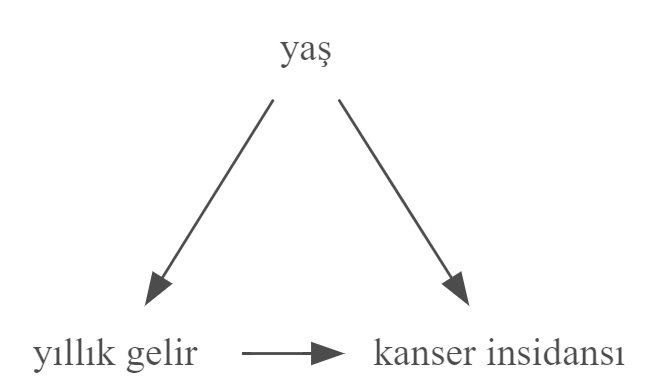

Örneğin,

- sigara içme ile akciğer kanseri arasındaki ilişkiyi araştırırken, “yaş” bozucu bir değişken olabilir. Yaş, hem sigara içme olasılığıyla hem de akciğer kanseri riskini artıran bir faktör olduğundan, bağımsız değişken (sigara) ve bağımlı değişken (akciğer kanseri) arasındaki ilişkiyi bozabilir

Örneğin,

- dondurma tüketimi ile boğulma vakaları arasında bir ilişki gözlemlenebilir; ancak bu iki değişkenin ilişkisini aslında hava sıcaklığı (bozucu değişken) açıklar. Sıcak hava, hem dondurma tüketimini artırır hem de insanların yüzmeye gitme olasılığını ve dolayısıyla boğulma vakalarının sayısını artırır. Bu durumda, dondurma tüketimi ve boğulma vakaları arasındaki ilişkiyi doğru anlamak için hava sıcaklığını dikkate almak gereklidir.

# Bastırıcı Değişken (suppressor)

Bastırıcı değişken, regresyon analizinde bağımsız değişkenlerden biriyle yüksek korelasyon gösteren ancak bağımlı değişkenle doğrudan ilişki göstermeyen bir değişkendir. Bastırıcı değişkenin modele eklenmesi yani kontrol edilmesi, diğer bağımsız değişkenlerin bağımlı değişken üzerindeki etkisini daha net ortaya çıkarabilir. Bu durum, bastırıcı değişkenin varlığıyla birlikte diğer değişkenlerin regresyon katsayılarının anlamlı hale gelmesiyle veya artması ile kendini gösterir.

Örnek durumlar:

- stres düzeyi ile iş performansı arasındaki ilişkiyi inceliyorsunuz. Ancak, öz denetim değişkeni bu ilişkide bastırıcı bir değişken olabilir. Öz denetim düzeyini kontrol ettiğinizde, stresin iş performansı üzerindeki etkisi daha belirgin hale gelebilir.
- öğretmenin öğretim tecrübesi ile öğrenci başarısı arasındaki ilişkiyi düşünelim. Eğer öğretmenlerin stres seviyesi bastırıcı bir değişkense, stres seviyesi modele dahil edilmediğinde öğretmenin öğretim tecrübesi ile öğrenci başarısı arasındaki ilişki zayıf görünebilir. Ancak, stres seviyesi kontrol edildiğinde, tecrübe ile başarı arasındaki ilişki daha güçlü olabilir.

# Aracı Değişken (mediator) ve Nedensellik

Bağımsız değişken ile bağımlı değişken arasındaki ilişkiyi açıklayan bir değişkendir. Korelasyon iki değişken arasındaki ilişki ve bu ilişkinin gücü ve yönü hakkında bilgi verebilir fakat hangi değişkenin diğerini etkilediği yani nedensellik hakkında bilgi vermez. Aslında X değişkeni Y değişkeninin nedeni ya da tam tersi veya her iki değişken de birbirinin nedeni olabilir. Tabi nedensellik için X ve Y arasında mutlaka bir ilişki olması gerektiği unutulmamalıdır. Nedenselliğin belirlenmesinde deneysel çalışmaların yanında kuramsal dayanakların da verilmesi gerekmektedir.

Aracı değişken diğer iki değişken arasındaki (genellikle iyi kurulmuş) bir ilişkinin nasıl veya neden olduğunu açıklar ve genellikle bir etkinin meydana geldiği süreci tanımladıkları için aracı değişkenler olarak adlandırılırlar.

Bir araştırmacının üçüncü değişken etkilerini araştırmaya başlamasının bir nedeni, bağımsız bir değişkenin bağımlı bir değişkeni etkilediği nedensel süreci, yani aracılık hipotezini aydınlatmaktır. Aracılık etkisine bazen dolaylı etki de denir.

Örneğin, daha yüksek gelirli insanlar daha uzun yaşama eğilimindedir, ancak bu etki daha iyi sağlık hizmetlerine erişimin aracı etkisiyle açıklanmaktadır.

- Örneğin eğitim seviyesinin iş performansı üzerindeki etkisinin incelendiği bir çalışmada
  - Bağımsız Değişken: Eğitim seviyesi
  - Aracı Değişken: İş tatmini
  - Bağımlı Değişken: İş performansı

Eğitim seviyesinin yüksek olması (bağımsız değişken), kişinin iş tatminini (aracı değişken) artırabilir ve bu da iş performansının (bağımlı değişken) artmasına yol açabilir. Burada eğitim seviyesinin iş performansına olan etkisi, iş tatmini aracılığıyla açıklanabilir.

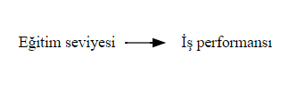

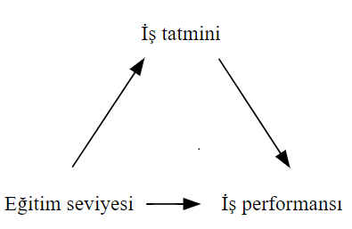

Bir aracılık hipotezinin incelenmesinde, bağımsız değişken ile bağımlı değişken arasındaki ilişki şekilde gösterildiği gibi iki nedensel yola ayrıştırılır. Bu yollardan biri bağımsız değişkeni bağımlı değişkene doğrudan (doğrudan etki), diğeri ise bağımsız değişkeni bağımlı değişkene bir aracı vasıtasıyla (dolaylı etki) bağlar. Dolaylı ya da aracı etki, bağımsız değişkenin aracı değişkene neden olduğu, aracı değişkenin de bağımlı değişkene neden olduğu anlamına gelir.

Bir örnek daha vermek gerekirse

- Teknoloji destekli eğitim (X) ile öğrenci başarısı (Y) arasındaki ilişkide, öğrencinin derse olan ilgisi (M) aracı bir değişken olabilir. Teknoloji destekli eğitim, öğrencinin ilgisini artırabilir, bu da dolaylı olarak öğrenci başarısını artırabilir.

R’da aracı etki, Baron & Kenny’nin (1986) 4 adımlı dolaylı etki yöntemi ve daha yeni olan `mediation` paketi (Tingley, Yamamoto, Hirose, Keele, & Imai, 2014) ile incelenebilir. Baron & Kenny (1986) yöntemi, aracılığı test etmek için kullanılan orijinal yöntemler arasındadır ancak düşük istatistiksel güce sahip olma eğilimindedir. Yine de değişkenler arasında ilişki kurmaya yönelik çok net bir yaklaşım sunmaktadır. Bununla birlikte, `mediation` paket yöntemi daha esnek ve istatistiksel olarak daha güçlü bir yaklaşım olarak şiddetle tavsiye edilmektedir.

# Varsayımların İncelenmesi

Aracılık analizi de dahil olmak üzere birçok istatistiksel analiz, verilerle ilgili belirli varsayımlara dayanır. Aracılık analizi regresyon analizi ile aynı varsayımlara sahiptir. Aslında çok değişkenli tüm istatistiksel analizlere başlamadan önce aşağıdaki varsayımların kontrol edilmesi gerekir.

- Varsayımların kontrolüne başlamadan önce veri setinde yanlış girilmiş bir değer olup olmadığı kontrol edilmelidir.

```r
araci <- readRDS("import/araci.Rds")
summary(araci)
```

```
##        X               M               Y
##  Min.   :158.8   Min.   :108.0   Min.   :38.55
##  1st Qu.:171.5   1st Qu.:117.7   1st Qu.:46.05
##  Median :175.4   Median :122.7   Median :49.57
##  Mean   :175.6   Mean   :122.4   Mean   :49.56
##  3rd Qu.:179.8   3rd Qu.:127.3   3rd Qu.:52.39
##  Max.   :190.3   Max.   :136.8   Max.   :63.82
```

Bu amaçla başka paket ve fonksiyonlar da kullanılabilir (Örneğin ‘psych’ paketi describe fonksiyonu).

-Kayıp/eksik veri olup olmadığı kontrol edilir, eğer varsa miktarı ve örüntüsüne göre uygun kayıp veri atama yöntemi seçilmelidir.

```r
library(naniar)
araci <- readRDS("import/araci.Rds")
any_na(araci)     # kayıp verinin olup olmadığı
```

```
## [1] FALSE
```

```r
n_miss(araci)     # toplam eksik veri sayısı
```

```
## [1] 0
```

```r
prop_miss(araci)  # eksik veri oranı
```

```
## [1] 0
```

```r
miss_var_summary(araci) # eksik veri tablosu
```

```
## # A tibble: 3 × 3
##   variable n_miss pct_miss
##   <chr>     <int>    <dbl>
## 1 X             0        0
## 2 M             0        0
## 3 Y             0        0
```

Veri seti ve yapısı incelendikten sonra varsayımlara geçebiliriz:

- Bağımsızlık: Gözlemlerin birbirlerinden bağımsız olması gerekmektedir. Hata terimlerinin ilişkisiz olduğunu belirlemenin en kolay yolu Durbin-Watson testini kullanmaktır.

```r
library(car)
model<-lm(Y~X+M, data=araci)
durbinWatsonTest(model)
```

```
##  lag Autocorrelation D-W Statistic p-value
##    1      0.05649613      1.829628   0.408
##  Alternative hypothesis: rho != 0
```

DW değeri için genelde 1.5-2.5 aralığı kabul edilebilir.Bu durumda hataların ilişkisiz olduğu söylenebilir.

- Doğrusallık : Değişkenler arasında doğrusal bir ilişki olmalıdır. Araci adlı veri setimizde bir bağımlı, bağımsız ve araci değişken olduğundan bu değişkenler arası doğrusal ilişkiler incelenmelidir. Değişken sayısı fazla olduğunda bu yol zahmetli olabilir. Bu yüzden doğrusallık incelemesi arıkların grafiği ile incelenebilir.

```r
dogrusallik <- plot(model,1)
```

[output not shown]

- Uç değerler : Veri setinde önemli sayıda uç değer olmamalıdır.

```r
ucdegerbsiz<-boxplot(araci$X, ylab= "saat")
ucdegerbli<-boxplot(araci$Y, ylab="uyanıklık derecesi")
ucdegeraraci<-boxplot(araci$M, ylab="kahve tüketimi")
```

[output not shown]

Tek değişkenli uç değer olup olmadığı z puanları hesaplanarak bulunur.

```r
library(outliers)
z.scores<-scores(araci, type="z")
round(head(z.scores),2)
```

[output not shown]

Çok değişkenli uç değerleri belirlemenin bir yolu Mahalanobis uzaklığını hesaplamaktır. Mahalanobis uzaklığı z puanının çok boyutlu versiyonudur.

```r
md <- mahalanobis(araci, center = colMeans(araci), cov = cov(araci))
alpha <- .001
cutoff <- (qchisq(p = 1 - alpha, df = ncol(araci))) # kritik değer belirleme
ucdegerler<-which(md>cutoff)
ucdegerler
```

```
## integer(0)
```

- Normallik : Hata terimlerinin normal dağılıp dağılmadığı incelenmelidir.

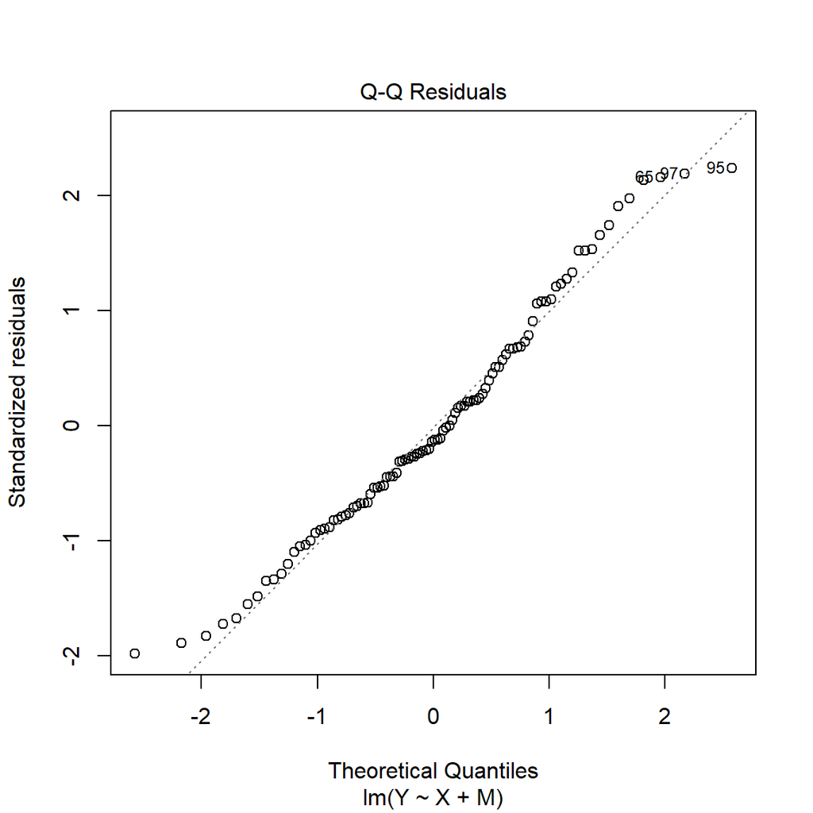

```r
plot(model,2)
```

```r
#hist(model$residuals, col='steelblue') histogramdan yararlanılır
```

Noktaların referans çizgisinden sapmaması beklendiğinden veri setinde hata terimlerinin dağılımı normaldir.

- Eş varyanslılık : Örneklemin aynı varyansa sahip bir evrenden geldiğini ifade eder ve normallik varsayımı ile ilişkilidir.Çok değişkenli normallik sayıltısı karşılandığında, değişkenler arasındaki ilişkiler homojendir.Varyansların homojenliği (homoscedasticity), bağımlı değişken(ler)in bağımsız değişken(ler)in aralığı boyunca aynı düzeyde varyansa sahip olduğu sayıltısıdır.

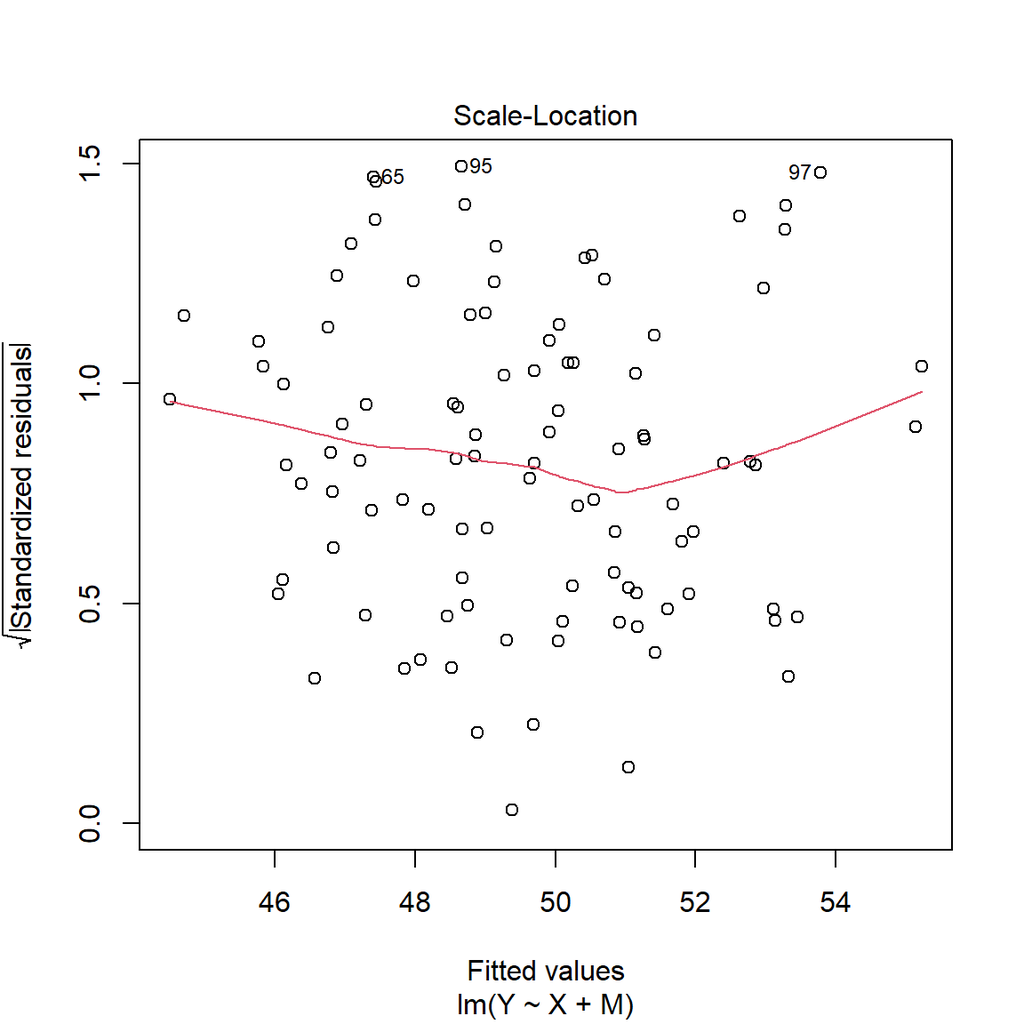

```r
plot(model,3)
```

Kırmızı çizgi yataylıktan biraz sapıyor.Heteroscedasticity’e ait kanıt yok. Normallik ve varyansların homojenliği sayıltıları ihlal edildiği zaman veri dönüştürme yapılabilir.

```r
library(MVN)  # çok değişkenli normalliğin incelenmesi
sonuc <- mvn(data = araci,mvnTest = "mardia")
sonuc$multivariateNormality
```

```
##              Test         Statistic           p value Result
## 1 Mardia Skewness  15.0117125447579 0.131635421156054    YES
## 2 Mardia Kurtosis 0.235841473141758 0.813555684815559    YES
## 3             MVN              <NA>              <NA>    YES
```

Mardia testi basıklık ve çarpıklık sonuçlarını verir ve p değerlerinin 0.05’ten büyük olması gerekir.

- Çoklu bağlantılılık : Hata terimleri arasında ilişki yüksek olmamalıdır.Çoklu bağlantı sorunu, yanlış tahminlere veya şişirilmiş standart hatalara yol açabileceğinden aracılık analizi sonuçlarında hataya neden olabilir.Bu nedenle aracılık analizine başlamadan önce bu varsayım kontrol edilmelidir.

```r
coklubag<-cor(araci)
round(coklubag,2)
```

```
##      X    M    Y
## X 1.00 0.66 0.21
## M 0.66 1.00 0.43
## Y 0.21 0.43 1.00
```

Değişkenler arası korelasyon dışında tolerance ve vıf değerleri kontrol edilmelidir.

```r
library(olsrr)
ols_vif_tol(model)
```

```
##   Variables Tolerance      VIF
## 1         X 0.5654493 1.768505
## 2         M 0.5654493 1.768505
```

Tolerance değeri için önerilen kesme değeri 0.10, VIF değeri için ise 10’dur.Bu veri setinde çoklu bağlantı sorunu yoktur.

# Farklı Modeller

Aracılık modelleri, modelde yer alan aracı değişken sayısına göre temelde tekli ve çoklu aracılık modelleri olarak kategorilendirilmektedir.Genelde tek bir aracı değişkenin yer aldığı tekli (basit) aracılık modelleri kullanılmasına rağmen birden çok aracılık etkisinin de değerlendirildiği çoklu aracılık modelleri (paralel-serial) kullanılabilir.

## Tekli Aracılık Modeli

Bağımlı ve bağımsız değişken arasındaki ilişkiyi tek bir aracı değişken açıklamaya çalışıyorsa tekli(basit) aracılık modeli kurulur. Bu modelin kavramsal gösterimi aracılık analizi başlığında denklemi ile birlikte verilmiştir.

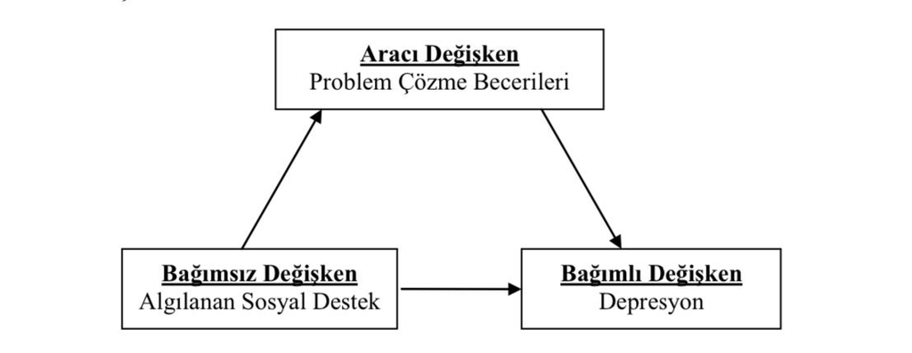

Basit Aracılık Modeli Örneği

## Çoklu Aracılık Modeli-Paralel

Bağımlı ve bağımsız değişken arasındaki ilişkiyi etkileyen birden fazla aracı değişken olması ve bu aracı değişkenlerin nedensel olarak birbirlerini etkilemediği durumda paralel çoklu aracılık modeli kurulur. İki aracı değişkenli paralel çoklu aracılık modeli diyagramı aşağıdaki görselde yer almaktadır.

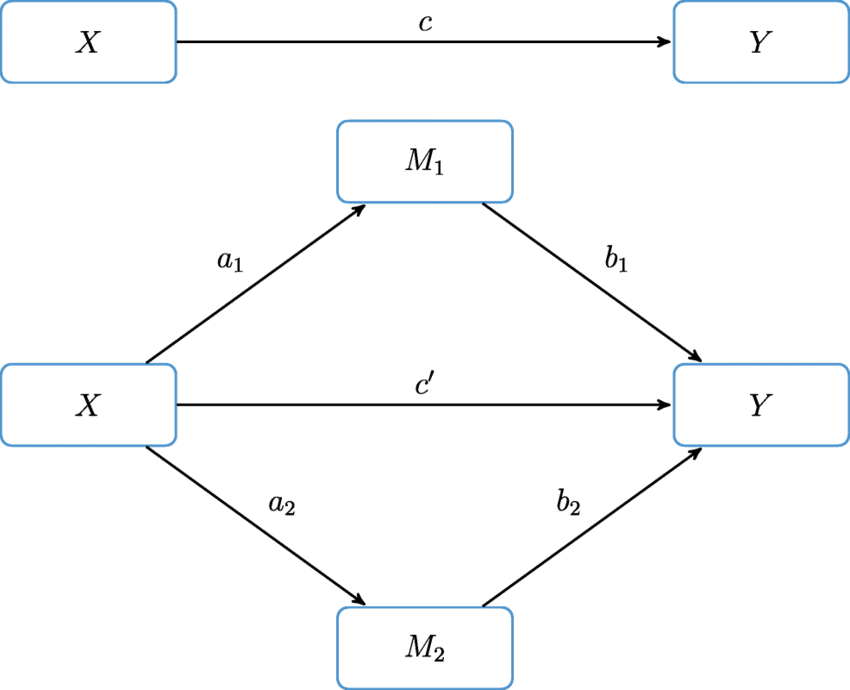

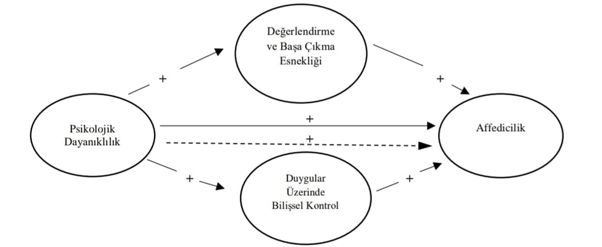

Burada dikkat edilmesi gereken nokta bu aracı değişkenlerin ilişkili olabileceği fakat bu değişken arasında nedensel bir ilişkinin olmadığıdır. Örneğin bilişsel esnekliğin bilişsel kontrol ile başa çıkma esnekliği faktörlerinin psikolojik dayanıklılık ve affedicilik arasındaki ilişkiye aracılık ettiğini ortaya koyan bir araştırmada iki aracı değişken arasında orta düzeyde bir ilişki bulunmuştur.

## Çoklu Aracılık Modeli-Serial

Bu çoklu aracılık modelinde ise en az iki aracı değişken arasında nedensel bir ilişki olduğu varsayılmaktadır. İki aracı değişken içeren seri çoklu aracılık modeli temel gösterimi aşağıda yer almaktadır.

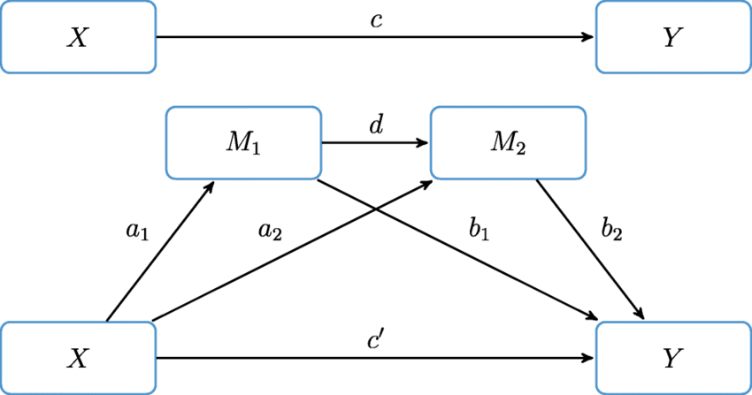

Burada M1’in M2’yi etkilediği (M2, M1’i etkilemez) kabul edilir ve matematiksel denklemler de buna göre yazılır.

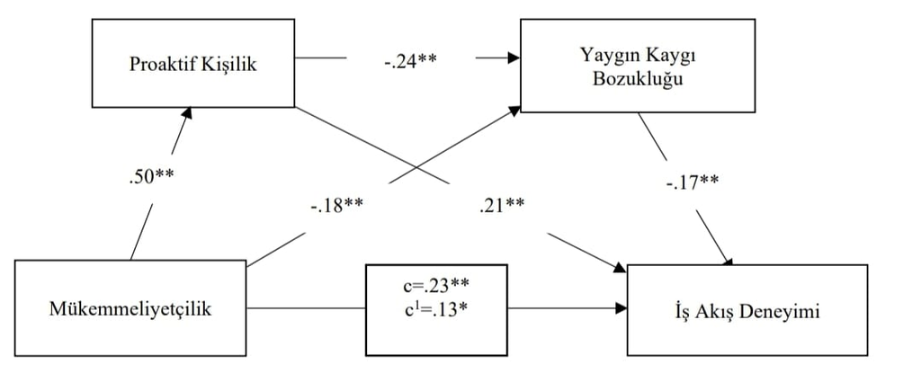

Çoklu aracılık modelleri sayesinde toplam etki ve aracılığın anlamlılığı daha detaylı tartışılabilir.Örneğin çalışanların mükemmeliyetçilik düzeyleri ile iş akış deneyimleri arasındaki ilişkide proaktif kişilik özelliğinin ve yaygın kaygı bozukluğunun seri çoklu aracılık etkisi olduğu ortaya konulduğu bir çalışmada, toplam etki ve aracılık anlamlı çıkmış, aracı değişkenler arasında negatif yönde anlamlı etki çıkmıştır.Burada aracılık anlamlı bulunmasına rağmen toplam etki anlamlı da çıkmayabilirdi.Çoklu aracılık modelleri bu tür durumların tespitinde önem arz etmektedir.

Buradan sonraki analizler en sık kullanılan tekli aracılık modeli üzerinden gerçekleştirilecektir.

## Aracılık Analizi

Aracılık, X’in (bağımsız) Y (bağımlı) üzerindeki etkilerinin üçüncü bir değişken olan M (aracı) üzerinden işleyip işlemediğini test eder. Bu şekilde, aracılar iki değişken arasındaki nedensel ilişkiyi veya ilişkinin “nasıl” işlediğini açıklar ve bu da onu psikolojik araştırmalarda çok popüler bir yöntem haline getirir.

Aracı değişkenler bir ilişkinin doğasını güçlendirebilir, zayıflatabilir veya tersine çevirebilir.

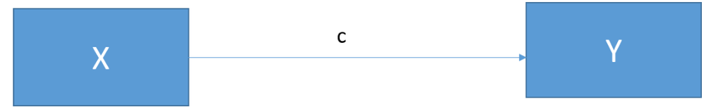

Toplam Etki Modeli

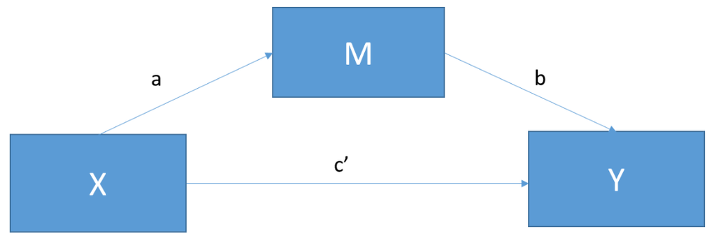

Standart Aracı Model

- c = X’in Y üzerindeki toplam etkisi
- c = c’ + ab
- c’= M’yi kontrol ettikten sonra X’in Y üzerindeki doğrudan etkisi;
- c’=c-ab
- ab= X’in Y üzerindeki dolaylı etkisi

Yukarıda standart aracılık modeli gösterilmektedir. Modeldeki M ile X’in Y üzerindeki etkisi 0’a düştüğünde mükemmel aracılık meydana gelir. Kısmi aracılık, X’in Y üzerindeki etkisi modeldeki M ile önemsiz olmayan bir miktarda (gerçek miktar tartışmaya açıktır) azaldığında ortaya çıkar.

### Yöntem 1: Baron & Kenny

Bu örnekte, şafaktan itibaren geçen saat sayısının (X), kahve tüketimi (M) yoluyla 100 yüksek lisans öğrencisinin öznel uyanıklık derecelerini (Y) etkileyip etkilemediğini inceleyeceğiz.

4 adımlı bu yöntemde adım 1 ve adım 2 temel doğrusal regresyonu kullanırken, adım 3 ve adım 4 çoklu regresyonu kullanır.

Adımlar:

1. X ile Y arasındaki ilişkiyi kestirin (şafaktan bu yana geçen saatler uyanıklığı etkiler)

   -“c” yolu 0’dan önemli ölçüde farklı olmalıdır; bağımsız değişken ve bağımlı değişken arasında toplam bir etkiye sahip olmalıdır
2. X ile M arasındaki ilişkiyi kestirin (şafaktan itibaren geçen saatler kahve tüketimini etkiler)
   - “a” yolu 0’dan önemli ölçüde farklı olmalıdır; bağımsız değişken ve aracı değişken ilişkili olmalıdır.
3. X’i kontrol ederek Y ile M arasındaki ilişkiyi kestirin (şafaktan bu yana geçen saatler kontrol edildiğinde kahve tüketiminin uyanıklığı etkiler)
   - “b” yolu 0’dan önemli ölçüde farklı olmalıdır; aracı değişken ve bağımlı değişken ilişkili olmalıdır.
   - X’in Y üzerindeki etkisi M’nin modele dahil edilmesiyle azalır.
4. M’yi kontrol ederek Y ile X arasındaki ilişkiyi kestirin (kahve tüketimini kontrol ederek uyanıklığın şafaktan itibaren geçen saatleri etkiler )
   - Anlamlı olmamalı ve yaklaşık 0 olmalıdır.

Öncelikle veri seti R ortamına aktarılır

```r
araci <- readRDS("import/araci.Rds")
```

Sonrasında her adım için model kurulur, bu modeller lavaan paketi ile de kurulabilir. Ancak `slazeger` paketinin çıktıları `lm()` fonksiyonu çıktıları ile uyumlu ve kullanışlıdır.

```r
library(stargazer) # Kullanışlı regresyon tabloları

#1. toplam etki
fit <- lm(Y ~ X, data=araci)

#2. YOL A (X on M)
fita <- lm(M ~ X, data=araci)

#3. YOL B (M on Y, X kontrol edildiğinde )
fitb <- lm(Y ~ M + X, data=araci)

#4. YOL C - ters yol (Y on X,  M  kontrol edildiğinde)
fitc <- lm(X ~ Y + M, data=araci)

# Özet tablo
stargazer(fit, fita, fitb, fitc, type = "text", title = "Baron and Kenny Yöntemi ile Aracılık Etkisi",digits = 2,
          font.size ="tiny")
```

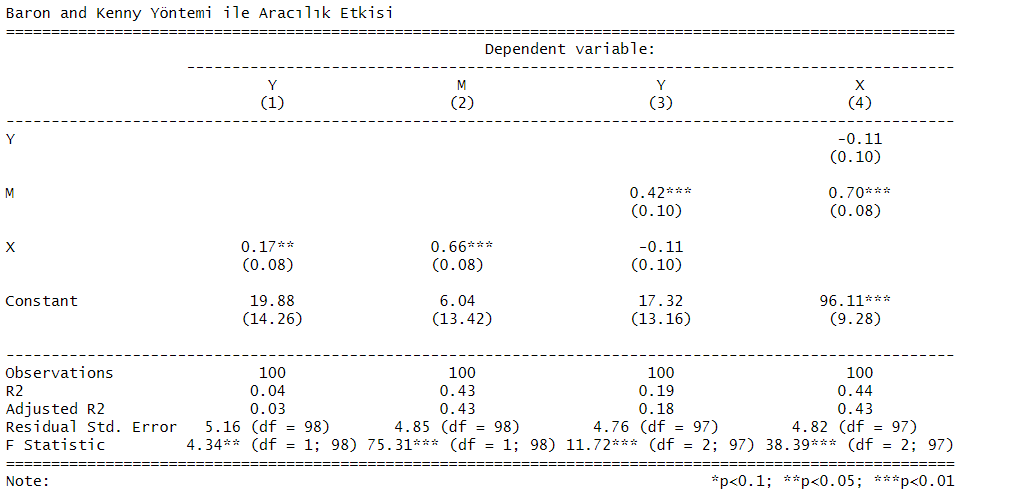

Burada, toplam etki modelimizin şafaktan bu yana geçen saat (X) ile uyanıklık (Y) arasında anlamlı bir pozitif ilişki gösterdiğini buluyoruz.

- Yol A modelimiz, şafaktan beri geçen saatlerin (X) kahve tüketimi (M) ile de pozitif ilişkisi olduğunu göstermektedir.
- Yol B modelimiz, kahve tüketiminin (M) şafaktan bu yana geçen saat (X) kontrol edildiğinde uyanıklığı (Y) pozitif olarak yordadığını göstermektedir.
- Son olarak, kahve tüketimi (M) kontrol edildiğinde uyanıklık (Y) şafaktan bu yana geçen süreyi (X) yordamamaktadır.

Kahve tüketimi kontrol edildiğinde şafaktan bu yana geçen saatler ile uyanıklık arasındaki ilişki artık anlamlı olmadığından, bu durum kahve tüketiminin aslında bu ilişkiye aracılık ettiğini göstermektedir. Ancak, bu yöntem tek başına dolaylı etkinin resmi olarak test edilmesine izin vermediğinden, bu ilişkideki değişimin gerçekten anlamlı olup olmadığını bilmiyoruz.

Dolaylı etkinin anlamlılığını test etmek için iki temel yöntem vardır: Sobel testi ve bootstrapping (*mediatation* yöntemi kapsamında). Sobel testi, `multilevel` paketinin `sobel()` fonksiyonu ile ya da `bda` paketini `mediation.test()` fonksiyonu ile yapılabilir.

```r
#Sobel Test
library(multilevel)
sobel(araci$X, araci$M, araci$Y)
```

```
## $`Mod1: Y~X`
##               Estimate Std. Error  t value   Pr(>|t|)
## (Intercept) 19.8836805 14.2637142 1.394004 0.16646905
## pred         0.1689931  0.0811601 2.082220 0.03992761
##
## $`Mod2: Y~X+M`
##               Estimate  Std. Error   t value     Pr(>|t|)
## (Intercept) 17.3217682 13.16215851  1.316028 1.912663e-01
## pred        -0.1117904  0.09949262 -1.123605 2.639537e-01
## med          0.4238113  0.09899469  4.281152 4.371472e-05
##
## $`Mod3: M~X`
##              Estimate  Std. Error   t value     Pr(>|t|)
## (Intercept) 6.0449365 13.41692114 0.4505457 6.533122e-01
## pred        0.6625203  0.07634187 8.6783345 8.871741e-14
##
## $Indirect.Effect
## [1] 0.2807836
##
## $SE
## [1] 0.07313234
##
## $z.value
## [1] 3.83939
##
## $N
## [1] 100
```

```r
#or
library(bda)
attach(araci)
mediation.test(M,X,Y)
```

```
##                Sobel       Aroian      Goodman
## z.value 3.8393902040 3.8190525305 3.8600562907
## p.value 0.0001233403 0.0001339652 0.0001133609
```

Sobel Testi, M mevcut olduğunda X’in Y üzerindeki etkisinde önemli bir azalma olup olmadığını belirlemek için özel bir t-testi kullanır. `multilevel` paketinin `sobel()` fonksiyonunu kullanmak size daha önce çalıştırdığımız üç temel modelin (Mod1 = Toplam Etki; Mod2 = Yol B; ve Mod3 = Yol A) yanı sıra dolaylı etkinin bir tahminini, bu etkinin standart hatasını ve bu etki için z-değerini gösterecektir. Bu değeri p-değerinizi hesaplamak için kullanabilir ya da `bda` paketinden `mediation.test()` fonksiyonunu çalıştırarak bu tahmin için bir p-değeri alabilirsiniz.

Bu durumda, şafaktan bu yana geçen saatler ile uyanıklık hissi arasındaki ilişkiye kahve tüketiminin önemli ölçüde aracılık ettiğini doğrulayabiliriz (z’ = 3.84, *p* < .001).

Bununla birlikte, Sobel Testi, dolaylı etkinin (ab) normal dağıldığını varsaydığı ve yalnızca büyük örneklem boyutlarında yeterli güce sahip olma eğiliminde olduğu için büyük ölçüde modası geçmiş bir yöntem olarak kabul edilmektedir. Bu nedenle, bunun yerine *aracılık* bootstrapping yönteminin kullanılması şiddetle tavsiye edilir.

### Yöntem 2: `mediate` Yöntemi

Bu paket, Sobel Testinin güç sınırlamalarını ele almak için Preacher & Hayes’in (2004) daha yeni bootstrapping yöntemini kullanmaktadır. Bu yöntem, dolaylı etkinin (ab) nokta tahminini çok sayıda rastgele örneklem (varsayılan olarak 1000) üzerinden hesaplar, bu nedenle verilerin normal dağıldığını varsaymaz ve özellikle küçük örneklem boyutları için Barron & Kenny yönteminden daha uygundur.

`mediate()` fonksiyonu çalıştırmak için, yine yukarıdaki Yol A modeli gibi aracı değişkeni (kahve tüketimi) kestiren bir bağımsız değişken modeline (şafaktan bu yana geçen saatler) gerek olacaktır. Ayrıca, aracı değişkeni (kahve tüketimi) kontrol ederken, bağımsız değişkenin (şafaktan bu yana geçen saat) bağımlı değişken (uyanıklık) üzerindeki doğrudan etkisinin bir modeli de kurulmalıdır. Daha sonra bu modeller arasında bir karşılaştırmayı tekrar tekrar simüle etmek ve kahve tüketiminin dolaylı etkisinin anlamlılığını test etmek için *mediate* kullanabilir.

Analize geçmeden önce varsayımları test etmek içi `gvlma` paketinin aynı isimli fonksiyonu da kullanılabilir.

```r
library(mediation)
library(gvlma)

fitM <- lm(M ~ X, data=araci) # şafaktan beri geçen saatlerin (X) kahve tüketimini (M) etkiler
fitY <- lm(Y ~ X + M, data=araci) # kahve tüketimi kontrol edilirken, şafaktan bu yana geçen saat uyanıklığı etkiler
```

```r
gvlma(fitM) # veri pozitif çarpıktır
```

```
##
## Call:
## lm(formula = M ~ X, data = araci)
##
## Coefficients:
## (Intercept)            X
##      6.0449       0.6625
##
##
## ASSESSMENT OF THE LINEAR MODEL ASSUMPTIONS
## USING THE GLOBAL TEST ON 4 DEGREES-OF-FREEDOM:
## Level of Significance =  0.05
##
## Call:
##  gvlma(x = fitM)
##
##                    Value p-value                   Decision
## Global Stat        8.833 0.06542    Assumptions acceptable.
## Skewness           6.314 0.01198 Assumptions NOT satisfied!
## Kurtosis           1.219 0.26949    Assumptions acceptable.
## Link Function      1.076 0.29959    Assumptions acceptable.
## Heteroscedasticity 0.223 0.63674    Assumptions acceptable.
```

```r
gvlma(fitY)
```

```
##
## Call:
## lm(formula = Y ~ X + M, data = araci)
##
## Coefficients:
## (Intercept)            X            M
##     17.3218      -0.1118       0.4238
##
##
## ASSESSMENT OF THE LINEAR MODEL ASSUMPTIONS
## USING THE GLOBAL TEST ON 4 DEGREES-OF-FREEDOM:
## Level of Significance =  0.05
##
## Call:
##  gvlma(x = fitY)
##
##                      Value p-value                Decision
## Global Stat        3.41844  0.4904 Assumptions acceptable.
## Skewness           1.85648  0.1730 Assumptions acceptable.
## Kurtosis           0.77788  0.3778 Assumptions acceptable.
## Link Function      0.71512  0.3977 Assumptions acceptable.
## Heteroscedasticity 0.06896  0.7929 Assumptions acceptable.
```

```r
fitMed <- mediate(fitM, fitY, treat="X", mediator="M")
summary(fitMed)
```

```
##
## Causal Mediation Analysis
##
## Quasi-Bayesian Confidence Intervals
##
##                Estimate 95% CI Lower 95% CI Upper p-value
## ACME             0.2792       0.1419         0.43  <2e-16 ***
## ADE             -0.1078      -0.3074         0.08   0.290
## Total Effect     0.1713       0.0148         0.33   0.046 *
## Prop. Mediated   1.5771       0.4722         7.67   0.046 *
## ---
## Signif. codes:  0 '***' 0.001 '**' 0.01 '*' 0.05 '.' 0.1 ' ' 1
##
## Sample Size Used: 100
##
##
## Simulations: 1000
```

`mediate()` fonksiyonu;

- Ortalama Nedensel Aracılık Etkilerini (Average Causal Mediation Effects,ACME)
- Ortalama Doğrudan Etkilerini (combined indirect and direct effect, ADE)
- Birleştirilmiş Dolaylı ve Doğrudan Etkilerini (Toplam Etki)
- Bu kestirimlerin oranını (Prop. Mediated)

verir.

Buradaki ACME, M’nin dolaylı etkisidir (toplam etki - doğrudan etki) ve dolayısıyla bu değer aracılık etkisinin anlamlı olduğunu göstermektedir

```r
#Bootstrap
fitMedBoot <- mediate(fitM, fitY, boot=TRUE, sims=999, treat="X", mediator="M")
summary(fitMedBoot)
```

```
##
## Causal Mediation Analysis
##
## Nonparametric Bootstrap Confidence Intervals with the Percentile Method
##
##                Estimate 95% CI Lower 95% CI Upper p-value
## ACME             0.2808       0.1439         0.43  <2e-16 ***
## ADE             -0.1118      -0.3023         0.10   0.286
## Total Effect     0.1690      -0.0071         0.35   0.066 .
## Prop. Mediated   1.6615      -5.4801        10.97   0.066 .
## ---
## Signif. codes:  0 '***' 0.001 '**' 0.01 '*' 0.05 '.' 0.1 ' ' 1
##
## Sample Size Used: 100
##
##
## Simulations: 999
```

Daha sonra bu sonucu **fitMedBoot** ile doğrulamak için bu karşılaştırmayı bootstrap yapabiliriz ve yine önemli bir aracılık etkisi (ACME = .28, *p* < .001) ve şafaktan bu yana geçen saatlerin doğrudan etkisi olmadığını (ADE = -0.11, *p* = .29) bulabiliriz. Ancak, artan güçle birlikte, bu analiz artık anlamlı bir toplam etki göstermemektedir.

# Önemli Notlar

- Aracılık modellerinde birden fazla bağımlı ve bağımsız değişken olabilir. Bu durumda tüm değişkenler aynı anda analize dahil edilebilir. Bu durumda yorumlama değişebilir.

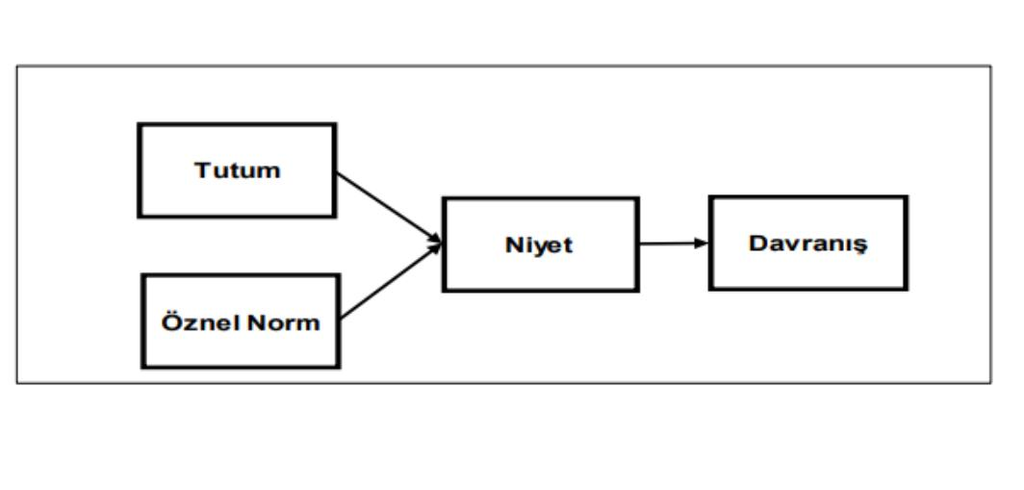

Öznel norm kontrol altına alındığında, tutumun niyet aracılığıyla davranış üzerindeki doğrudan ve dolaylı etkileri yorumlanır.Tabi X’ler arasında çoklu bağlantı sorunu olmadığına dikkat edilmelidir.

- Modelde yer alan bağımlı, bağımsız ve aracılık değişkenleri sürekli ya da kategorik olabilir. Tabi buna göre yorumlamalar değişebilir.
- Bağımlı ve bağımsız değişkenler arasındaki toplam etkiye göre belirlenen kısmi ve tam aracılık ayrımlarının kullanılması pek önerilmez (dolaylı etki/toplam etki önerilir).

## Kaynaklar

Baron, R., & Kenny, D. (1986). The moderator-mediator variable distinction in social psychological research: Conceptual, strategic, and statistical considerations. Journal of Personality and Social Psychology, 51, 1173-1182.

Hlavac, Marek (2022). stargazer: Well-Formatted Regression and Summary Statistics Tables. R package version 5.2.3. https://CRAN.R-project.org/package=stargazer

Tingley, D., Yamamoto, T., Hirose, K., Keele, L., & Imai, K. (2014). Mediation: R package for causal mediation analysis.